# Supplementary Information 1 - Global annual average reported landings of CMS Appendix I-listed species reported to FAO (2015-2019)

$~$

$~$

Each FAO area tab has a plot and a table representing the total landings of CMS Appendix I-listed species reported to FAO if data is available.

All landings are reported as tonnes of live weight.

Colour of nations within plots indicate Sharks MOU and CMS Status: (Dark blue) Sharks MOU Signatory and CMS Party; (light blue) Sharks MOU Signatory only; (green) CMS Party only; (grey) range state. Note that not all colours may be present in any given plot.

$~$

$~$

## Overview - All areas

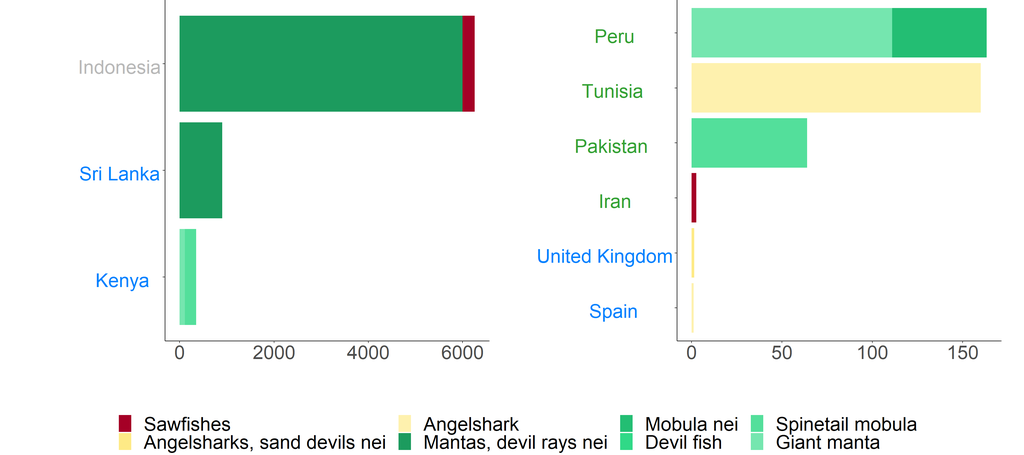

Overview all areas

| Country | Sharks MOU Status | CMS Status | Angelshark | Angelsharks, sand devils nei | Devil fish | Giant manta | Mantas, devil rays nei | Mobula nei | Sawfishes | Spinetail mobula | Yearly Average Total |
| --- | --- | --- | --- | --- | --- | --- | --- | --- | --- | --- | --- |
| Indonesia | Range State | Non-Party | - | - | - | - | 5999.40 | - | 256.80 | - | 6256.20 |
| Sri Lanka | MOU Signatory | Party | - | - | - | - | 901.10 | - | - | - | 901.10 |
| Kenya | MOU Signatory | Party | - | - | - | 111.00 | - | - | - | 240.00 | 351.00 |
| Peru | Range State | Party | - | - | - | 111.00 | - | 52.38 | - | - | 163.38 |
| Tunisia | Range State | Party | 160.00 | - | - | - | - | - | - | - | 160.00 |
| Pakistan | Range State | Party | - | - | - | - | - | - | - | 64.00 | 64.00 |
| Iran | Range State | Party | - | - | - | - | - | - | 2.60 | - | 2.60 |
| United Kingdom | MOU Signatory | Party | - | 1.40 | - | - | - | - | - | - | 1.40 |
| Spain | MOU Signatory | Party | 1.09 | - | 0.02 | - | - | - | - | - | 1.11 |

$~$

$~$

# By FAO Area (Choose a tab to display)

$~$

$~$

## Area 21 - Atlantic, Northwest

$~$

$~$

Area 21 - Atlantic, Northwest

$~$

```
## [1] "No data reported"
```

Area 21

| x |
| --- |
| No data reported |

## Area 27 - Atlantic, Northeast

$~$

$~$

Area 27 - Atlantic, Northeast

$~$

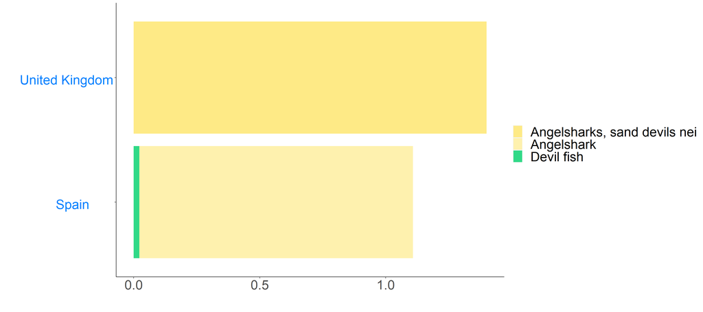

Area 27

| Country | Sharks MOU Status | CMS Status | Angelshark | Angelsharks, sand devils nei | Devil fish | Yearly Average Total |
| --- | --- | --- | --- | --- | --- | --- |
| United Kingdom | MOU Signatory | Party | - | 1.40 | - | 1.40 |
| Spain | MOU Signatory | Party | 1.09 | - | 0.02 | 1.11 |

## Area 31 - Atlantic, Western Central

$~$

$~$

Area 31 - Atlantic, Western Central

```
## [1] "No data reported"
```

Area 31

| x |
| --- |
| No data reported |

## Area 34 - Atlantic, Eastern Central

$~$

$~$

Area 34 - Atlantic, Eastern Central

$~$

```
## [1] "No data reported"
```

Area 34

| x |
| --- |
| No data reported |

## Area 37 - Mediterranean and Black Sea

$~$

$~$

Area 37 - Mediterranean and Black Sea

$~$

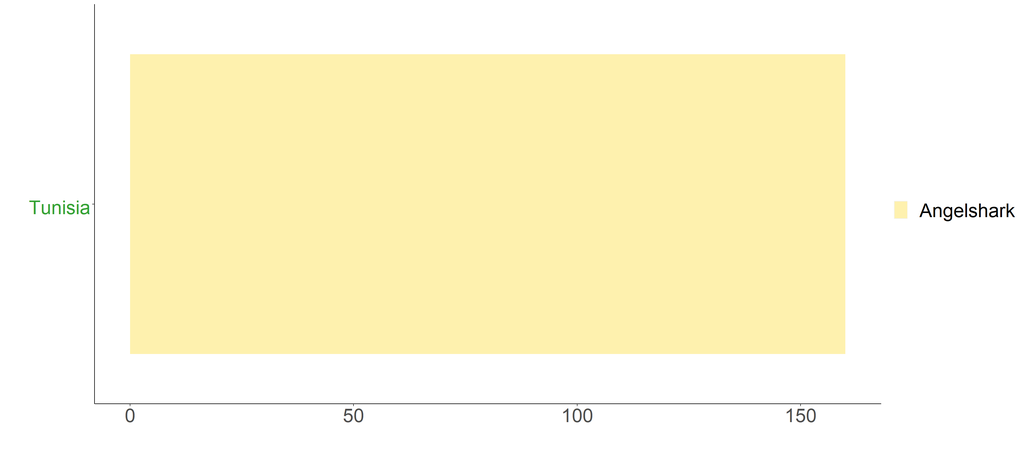

Area 37

| Country | Sharks MOU Status | CMS Status | Angelshark | Yearly Average Total |
| --- | --- | --- | --- | --- |
| Tunisia | Range State | Party | 160.00 | 160.00 |

## Area 41 - Atlantic, Southwest

$~$

$~$

Area 41 - Atlantic, Southwest

$~$

```
## [1] "No data reported"
```

Area 41

| x |
| --- |
| No data reported |

## Area 47 - Atlantic, Southeast

$~$

$~$

Area 47 - Atlantic, Southeast

$~$

```
## [1] "No data reported"
```

Area 47

| x |
| --- |
| No data reported |

## Area 51 - Indian Ocean, Western

$~$

$~$

Area 51 - Indian Ocean, Western

$~$

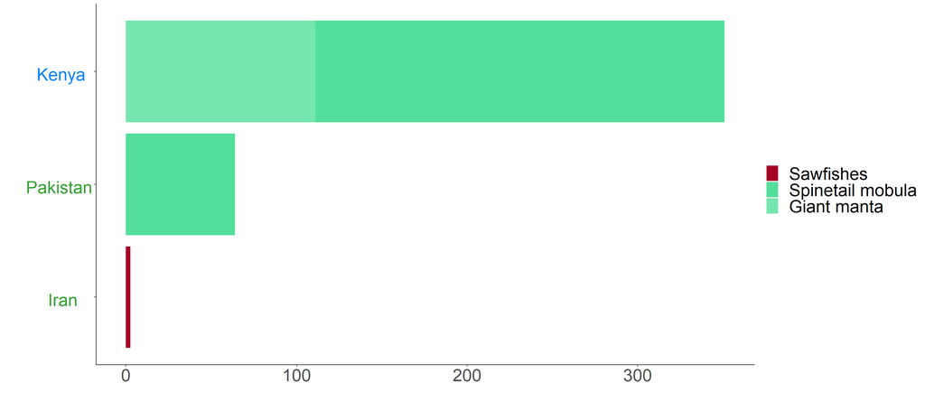

Area 51

| Country | Sharks MOU Status | CMS Status | Giant manta | Sawfishes | Spinetail mobula | Yearly Average Total |
| --- | --- | --- | --- | --- | --- | --- |
| Kenya | MOU Signatory | Party | 111.00 | - | 240.00 | 351.00 |
| Pakistan | Range State | Party | - | - | 64.00 | 64.00 |
| Iran | Range State | Party | - | 2.60 | - | 2.60 |

## Area 57 - Indian Ocean, Eastern

$~$

$~$

Area 57 - Indian Ocean, Eastern

$~$

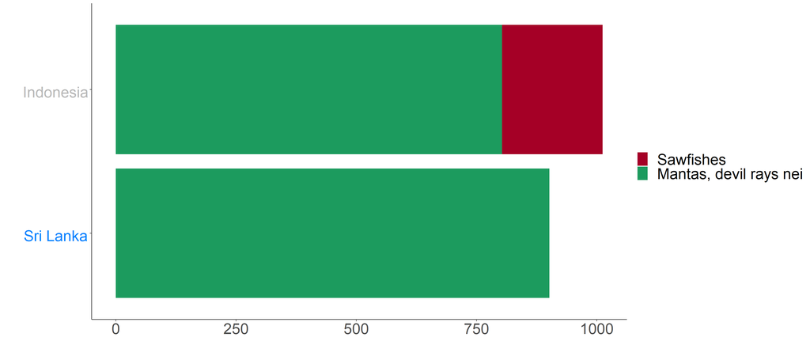

Area 57

| Country | Sharks MOU Status | CMS Status | Mantas, devil rays nei | Sawfishes | Yearly Average Total |
| --- | --- | --- | --- | --- | --- |
| Indonesia | Range State | Non-Party | 803.00 | 208.80 | 1011.80 |
| Sri Lanka | MOU Signatory | Party | 901.10 | - | 901.10 |

## Area 61 - Pacific, Northwest

$~$

$~$

Area 61 - Pacific, Northwest

$~$

```
## [1] "No data reported"
```

Area 61

| x |
| --- |
| No data reported |

## Area 67 - Pacific, Northeast

$~$

$~$

Area 67 - Pacific, Northeast

$~$

```
## [1] "No data reported"
```

Area 67

| x |
| --- |
| No data reported |

## Area 71 - Pacific, Western Central

$~$

$~$

Area 71 - Pacific, Western Central

$~$

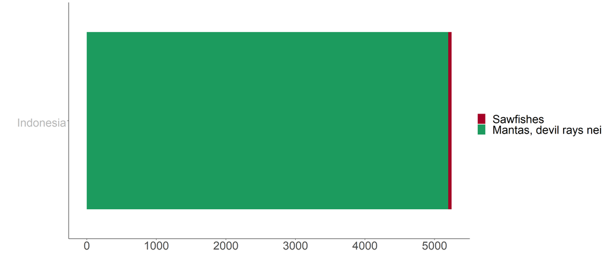

Area 71

| Country | Sharks MOU Status | CMS Status | Mantas, devil rays nei | Sawfishes | Yearly Average Total |
| --- | --- | --- | --- | --- | --- |
| Indonesia | Range State | Non-Party | 5196.40 | 48.00 | 5244.40 |

## Area 77 - Pacific, Eastern Central

$~$

$~$

Area 77 - Pacific, Eastern Central

$~$

```
## [1] "No data reported"
```

Area 77

| x |
| --- |
| No data reported |

## Area 81 - Pacific, Southwest

$~$

$~$

Area 81 - Pacific, Southwest

$~$

```
## [1] "No data reported"
```

Area 81

| x |
| --- |
| No data reported |

## Area 87 - Pacific, Southeast

$~$

$~$

Area 87 - Pacific, Southeast

$~$

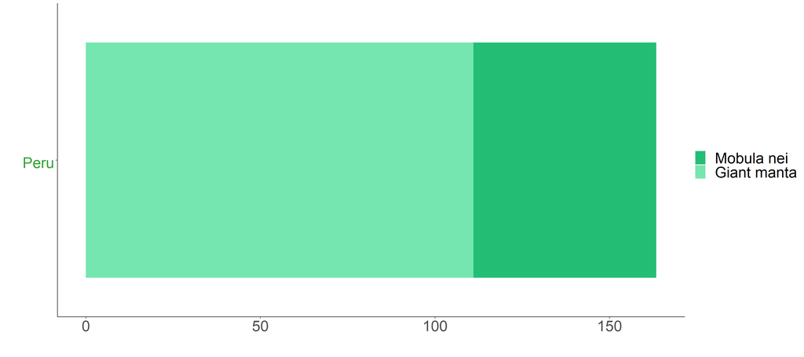

Area 87

| Country | Sharks MOU Status | CMS Status | Giant manta | Mobula nei | Yearly Average Total |
| --- | --- | --- | --- | --- | --- |
| Peru | Range State | Party | 111.00 | 52.38 | 163.38 |

## Area SO - Antartic

$~$

$~$

Area SO - Antartic

$~$

```
## [1] "No data reported"
```

Area SO

| x |
| --- |
| No data reported |

$~$

$~$